# Teaching Through Designed Friction

Day 1 · Notice what ease hides

Dr. Hongshan Guo

Thursday, 27 August 2026

## The question for today

Incoming teachers · experienced researchers

When should learning stay hard?

Not because struggle is good.  
Because some thinking must remain visible.

Today: notice what AI makes easy, then experience one useful challenge.

## Today’s one-hour plan

1 · CaseShare where GenAI made teaching harder.

2 · DiagnoseName what became harder to see—and what thinking must stay visible.

3 · TestUse dimensions and a reading to challenge your explanation.

4 · TryAnswer one sustained Oracle challenge.

5 · SaveKeep one short episode for Day 2.

DAY 1 What changed? What did the challenge make visible?

DAY 2 What should a learner have to do?

## Activity 1 · Start with one hard teaching case

OPENING ROUND · YOU MAY PASS “ You probably have stories about how GenAI has helped you learn. Share one case where that same help may have made teaching harder. What became harder—and why? ”

**Keep it brief:** one or two sentences. The case may come from your learning, teaching, supervision, or something you observed. Do not solve it yet.

## Activity 2 · Make the teaching problem specific

In that case, what became harder for the teacher to…

seejudgesupportassess questionrespond togive feedback on

HARD STOP Name the teaching problem—not the AI tool.

## Write down the before and after

1LearnerWhat were they trying to understand, decide, or make?

2GenAI easedWhat did GenAI make easier?

3TeachingWhat became harder to see, judge, or support?

4ConsequenceWhat feedback or teaching decision was affected?

5EvidenceWhat can you point to rather than assume?

Evidence may be a changed draft, explanation, decision, oral response, or missing process trace. Do not infer intent from fluent output alone.

## Pair exchange · Name the hidden teaching problem

A Tell the case plainly.

B Ask what became harder to see or judge.

SWAP Repeat.

“If the output vanished, what thinking would the learner have to do?”

“What could the teacher no longer see or confidently judge?”

“What evidence would separate learning from fluent output?”

Leave with one sentence: **GenAI made ___ easier; teaching became harder because ___.**

## Word cloud · What thinking must stay visible?

LIVE WORD CLOUD · YOU MAY PASS

When teaching, supervising, or running a crit, what kind of thinking do you need to see the learner doing?

explaincomparejustifyinterprettestrevisedecidecritique

SCAN OR CLICK

[figure not shown]

MENTI.COM **6434 0765**

**Submit one doing word**Scan, click, or enter the code above. Repeats are useful.

**No teaching résumé required**Answer from learning, crits, tutoring, TA work, supervision, or observation.

Now look at the cloud: **which kind of thinking becomes hardest to see when GenAI produces the finished output?**

## Visual check · What repeats?

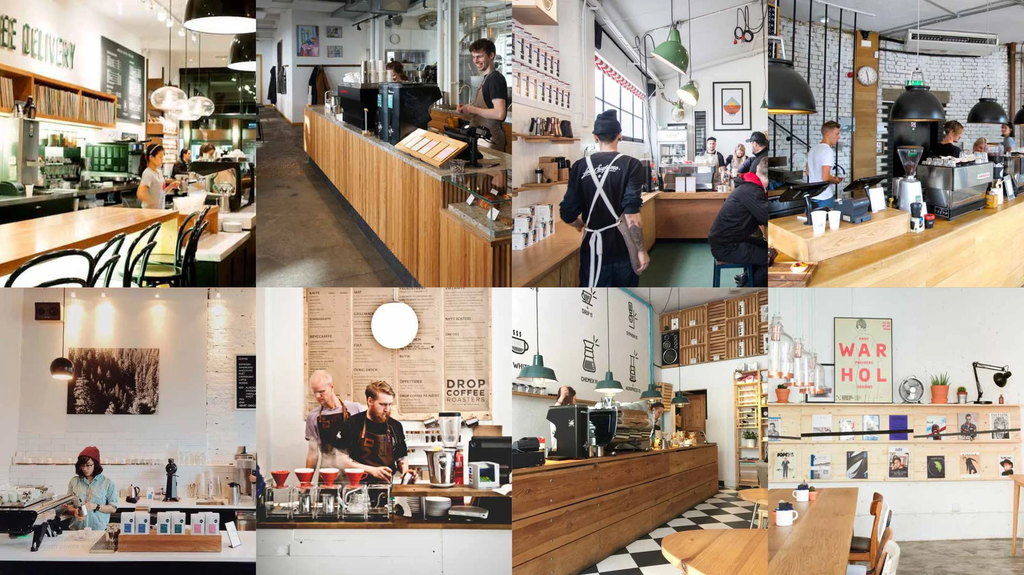

**Different cities.****Same coffee shop.**

[figure not shown]

**Different films.****Same poster.**

**Scan before we explain:** What repeats? What starts to feel “natural” only because it is familiar?

**The “average” arrived before generative AI.** Markets, platforms, and templates already rewarded recognizable formulas. GenAI can make variations within those formulas much faster.

Visual examples reproduced in Alex Murrell, [*The Age of Average*](https://www.alexmurrell.co.uk/articles/the-age-of-average). Cultural/design provocation—not a technical model of LLM sampling.

## 2025’s word of the year: “slop”

WORD OF THE YEAR · 2025 **SLOP** MERRIAM-WEBSTER

**In plain English:** low-quality digital content made in bulk, usually with AI.

OUTPUT IS CHEAP**→**JUDGMENT IS NOT

If polished output becomes plentiful, **what does a teacher now need to see?**

Source: Merriam-Webster, [*2025 Word of the Year: Slop*](https://www.merriam-webster.com/wordplay/word-of-the-year). Not all AI output is slop; fluency can still hide thin thinking.

## Every important choice adds a dimension

**1D · line**one parameter

→

**2D · plane**two parameters

→

**3D · volume**three parameters

→

**8D · cannot draw**still navigable

Each important instruction places a point in the space. **You choose the coordinates.**

## Activity 3 · Keep one thinking move with the learner

ZERO

“Give feedback.”

ONE

“Test the evidence.”

MANY

“Test this claim against this evidence; ask, don’t rewrite.”

**Complete all three:** AI may help with ___ · the learner must still ___ · I will see that thinking in ___.

## A better answer is not the same as better learning

1**Result**

Is the answer, design, or decision better?

OUTPUT

2**Work**

What thinking did the person still do?

PROCESS

3**Self-check**

Do they know what they understand—and what they do not?

JUDGMENT

4**Visible evidence**

Can a teacher or peer see the reasoning?

TRACE

The output can improve while the work, self-check, or visible evidence shrinks—or moves somewhere else.

## Reading check · Challenge your first explanation

USE ONE READING · DO NOT FORCE A FIT “ Which reading helps you explain the case? What does it let you claim—and what can it not establish? Does your first explanation still hold? ”

**Leave with:** one reading lens, one limit, and one revised explanation. You may conclude that none of the studies explains the case well.

Required: [Lee et al.](https://doi.org/10.1145/3706598.3713778) · [Kosmyna et al.](https://arxiv.org/abs/2506.08872) + [comment](https://arxiv.org/abs/2601.00856) · Recommended: [Fernandes et al.](https://doi.org/10.1016/j.chb.2025.108779) · [METR](https://arxiv.org/abs/2507.09089) + [update](https://metr.org/blog/2026-02-24-uplift-update/)

## Activity 4 · Change the AI’s job: from doing to asking

[LIVE TOOL**https://socraticoracle.netlify.app/****OPEN ↗**](https://socraticoracle.netlify.app/)

COMMON ROLE

AI makes something

draft · summary · image · code · answer

⇢

TODAY’S JOB

AI asks a question

What supports this? What else could explain it? Where does the claim stop?

**ASK**Don’t rewrite.

**ONE ISSUE**Press, then stay with it.

**FOLLOW**Build from the answer.

**NO VERDICT**The researcher decides.

A fluent question may still be wrong. You decide whether its premise holds.

## What the Oracle does with a paper

PAPER MAP

main claims

evidence

method

limits

why it matters

→

claim + evidence

method + measure

other explanation

limit + trade-off

→

?

one selected issue  
one question at a time

The map stays hidden. The system picks one issue and follows it. It may be incomplete or wrong.

## Local voice does not mean a local session

IN THIS BROWSER TAB

**Raw PDF · full extracted text · microphone audio**

Speech becomes an editable transcript here. You check it before sending.

TO BUILD THE MAP →  
selected paper text  
FOR EACH TURN →  
checked response + relevant passages + recent turns

OUTSIDE SERVICE

**Text is processed by the model**

The service produces the first question, follow-up, repair, or closing recap.

**Raw PDF and audio are not sent.** Some extracted text and every response you send are.

**Research sharing is a separate option.** The current site starts with that box checked.

BEFORE START: UNCHECK “SHARE THIS SESSION WITH THE RESEARCH TEAM” · USE ONLY SAFE, AUTHORIZED MATERIAL

Current interface: socraticoracle.netlify.app · Recheck the live disclosure and sharing default before delivery.

## Choose a safe way to take part

A · YOUR MATERIAL

Safe, approved text

Use only text you are allowed to send to an outside service.

B · SUPPLIED

Workshop sample

Use the fictional sample. This is the default whenever you are unsure.

C · NO UPLOAD

Paired or printed route

Answer prepared questions, or work from the supplied trace.

Personal material is not better evidence. You may type, pass, change routes, or stop.

## One voice turn has five steps

ReadA paper-based question appears as text.

SpeakAnswer aloud in your own words.

CheckThe browser creates an editable transcript.

SendThe reviewed text becomes your turn.

ContinueThe next question follows the same issue.

**The Oracle does not speak aloud.** Voice is the learner’s input; tutor responses are displayed as text.

## Before you start, set your own ground rules

EXPECT

What issue do you think the system may question?

ANCHOR

What evidence or rule will help you judge the question?

WATCH

Do you tend to rush, defend, over-explain, go blank, or become curious?

STOP

What would make you ask for simpler wording, reject the premise, or stop?

The system chooses the issue. You choose your evidence standard—and when to stop.

## Four honest ways to answer

D

Defend

N

Narrow

C

Challenge

?

Not yet

“I cannot answer that yet; I would need ___.”

**Also legitimate:** “Please rephrase that.” · “This is repeating the issue.” · “I want to stop.”

## Your turn · Try one issue—not the whole paper

YOUR CHOSEN ROUTE

**1 · START**Use safe text or the sample. If live, turn research sharing off.

**2 · ANSWER**Read the question. Give your real reasoning—not a polished speech.

**3 · CHECK**Fix speech-recognition errors. Mark any change to your actual answer.

**4 · STAY**Follow the same issue until the system closes it—or until you stop.

Do not analyze the transcript yet. First notice what the questioning makes you do.

## The system may stop; you may stop sooner

RECAP**A short summary with no new question**

→

ISSUE REVIEWED**The system pauses this line of questions**

→

YOUR CHOICE**Examine another issue—or end the session**

A system stopping point is not proof that the model is right—or that the research issue is settled.

## Activity 5 · First notice what happened

YOUR FIRST REACTION

pause · rush · defend · wonder · go blank

THINKING YOU DID

remember · explain · compare · limit · challenge · leave open

WHAT MADE IT HARD

the idea · speech · language · technology · being observed

WHAT HELPED YOU

evidence · simpler wording · typing · more space · stopping

## Prepare one short episode for Day 2

01**Save privately**

Download the full record. Do not send it to anyone.

02**Choose**

Pick one short exchange to help you remember the experience.

03**Remove details**

Delete names, filenames, sensitive context, and restricted content.

04**Mark one moment**

Underline where the question made you explain, change, resist, or stop.

BRING FOR PRIVATE RECALL ONLY · KEEP PRIVATE: THE EPISODE, FULL JSON, FULL TRACE, AND YOUR REFLECTION

## Tomorrow: turn the experience into a teaching move

WHAT HAPPENED?**What did the question make you think through?**

→

WAS IT USEFUL?**Did the difficulty reveal thinking—or just get in the way?**

→

DESIGN**What should a learner have to do and reveal?**

Do not make everything harder.  
**Make the important thinking visible—then get out of the way.**

Exit privately: “The question made me ______; my thinking became visible when ______.”